# Final Flanker Accuracy Analyses

PD Inhibition Project

Michael Hallquist

28 May 2020

This file contains final MLMs for accuracy statistics on the flanker task for the PD Inhibition DDM project.

## m0: design effects, no interaction, random intercept of subject

```r
minfo <- list() #re-initialize now that we're eliminating l1 heterogeneity
minfo[["m0"]] <- c(fixed="Congruency, Block", l2="Subject: Intercept")
```

```r
m0 <- glmer(correct ~ cond + block + (1|id),
          na.action = na.exclude,
          data = flanker, family=binomial)
```

```r
flextable(car::Anova(m0, type=3) %>% rownames_to_column("Predictor")) %>% autofit()
```

| Predictor | Chisq | Df | Pr(>Chisq) |
| --- | --- | --- | --- |
| (Intercept) | 879.4 | 1 | 2.89e-193 |
| cond | 164.2 | 1 | 1.37e-37 |
| block | 3.5 | 1 | 6.12e-02 |

```r
flextb_vif(m0)
```

| Predictor | vif |
| --- | --- |
| cond | 1.14 |
| block | 1.14 |

```r
emmeans(m0, ~cond|block, type="response")
```

```
## block = most_incon:
##  cond         prob      SE  df asymp.LCL asymp.UCL
##  congruent   0.993 0.00112 Inf     0.991     0.995
##  incongruent 0.973 0.00359 Inf     0.965     0.979
##
## block = most_con:
##  cond         prob      SE  df asymp.LCL asymp.UCL
##  congruent   0.992 0.00123 Inf     0.989     0.994
##  incongruent 0.967 0.00461 Inf     0.957     0.975
##
## Confidence level used: 0.95
## Intervals are back-transformed from the logit scale
```

```r
anova(m0)
```

```
## Analysis of Variance Table
##       npar Sum Sq Mean Sq F value
## cond     1  157.9   157.9  157.95
## block    1    3.3     3.3    3.29
```

## m1: design effects, random intercept of subject

Allow for interaction of congruency and block

```r
minfo[["m1"]] <- c(fixed="Congruency, Block, Congruency x Block", l2="Subject: Intercept")
```

```r
m1 <- glmer(correct ~ cond*block + (1|id),
          na.action = na.exclude,
          data = flanker, family=binomial)
```

```r
#flextable(anova(m1) %>% rownames_to_column("Effect")) %>% autofit() #lmerTest reports Satterthwaite degrees of freedom
flextable(car::Anova(m1, type=3) %>% rownames_to_column("Predictor")) %>% autofit()
```

| Predictor | Chisq | Df | Pr(>Chisq) |
| --- | --- | --- | --- |
| (Intercept) | 563.3978 | 1 | 1.53e-124 |
| cond | 54.7274 | 1 | 1.38e-13 |
| block | 0.0216 | 1 | 8.83e-01 |
| cond:block | 0.7713 | 1 | 3.80e-01 |

```r
flextb_vif(m1)
```

| Predictor | vif |
| --- | --- |
| cond | 2.86 |
| block | 4.74 |
| cond:block | 4.75 |

```r
anova(m1)
```

```
## Analysis of Variance Table
##            npar Sum Sq Mean Sq F value
## cond          1  159.0   159.0  158.95
## block         1    3.3     3.3    3.34
## cond:block    1    0.7     0.7    0.72
```

```r
flextable(as.data.frame(emmeans(m1, ~cond|block, type="response")) %>% dplyr::select(-df)) %>%
  colformat_num(j=c("prob", "SE", "asymp.LCL", "asymp.UCL"), digits=3)  %>% autofit()
```

| cond | block | prob | SE | asymp.LCL | asymp.UCL |
| --- | --- | --- | --- | --- | --- |
| congruent | most_incon | 0.993 | 0.002 | 0.989 | 0.995 |
| incongruent | most_incon | 0.973 | 0.004 | 0.965 | 0.979 |
| congruent | most_con | 0.992 | 0.001 | 0.989 | 0.994 |
| incongruent | most_con | 0.966 | 0.005 | 0.955 | 0.975 |

```r
flextable(render_aictab(minfo=minfo, m0, m1)) %>% autofit()
```

| model | fixed | l2 | logLik | AIC | dAIC | df | weight |
| --- | --- | --- | --- | --- | --- | --- | --- |
| m0 | Congruency, Block | Subject: Intercept | -2024 | 4056 | 0.00 | 4 | 0.655 |
| m1 | Congruency, Block, Congruency x Block | Subject: Intercept | -2024 | 4057 | 1.28 | 5 | 0.345 |

## m2: design effects, allow for L2 random intercept to vary by block

Use nested RE specification.

```r
minfo[["m2"]] <- c(
  fixed="Congruency, Block",
  l2="Subject: Intercept\nBlock within subject: Intercept")
```

```r
m2 <- glmer(correct ~ cond + block + (1|id/block),
          na.action = na.exclude,
          data = flanker, family=binomial, nAGQ=1)
```

```r
car::Anova(m2, type=3)
```

```
## Analysis of Deviance Table (Type III Wald chisquare tests)
##
## Response: correct
##              Chisq Df Pr(>Chisq)
## (Intercept) 871.01  1     <2e-16 ***
## cond        167.55  1     <2e-16 ***
## block         5.65  1      0.017 *
## ---
## Signif. codes:  0 '***' 0.001 '**' 0.01 '*' 0.05 '.' 0.1 ' ' 1
```

```r
anova(m2)
```

```
## Analysis of Variance Table
##       npar Sum Sq Mean Sq F value
## cond     1  150.7   150.7  150.71
## block    1    5.5     5.5    5.46
```

```r
flextable(render_aictab(minfo=minfo, m0, m1, m2)) %>% autofit()
```

| model | fixed | l2 | logLik | AIC | dAIC | df | weight |
| --- | --- | --- | --- | --- | --- | --- | --- |
| m0 | Congruency, Block | Subject: Intercept | -2024 | 4056 | 9.43 | 4 | 0.00882 |
| m1 | Congruency, Block, Congruency x Block | Subject: Intercept | -2024 | 4057 | 10.71 | 5 | 0.00466 |
| m2 | Congruency, Block | Subject: Intercept Block within subject: Intercept | -2018 | 4047 | 0.00 | 5 | 0.98652 |

## m3: Add trial_z as fixed

Non-significant effect – do not pursue

```r
minfo[["m3"]] <- c(
  fixed="Congruency, Block, Trial",
  l2="Subject: Intercept\nBlock within subject: Intercept")
```

```r
m3 <- glmer(correct ~ cond + block + trial_z + (1|id/block),
          na.action = na.exclude,
          data = flanker, family=binomial)
```

```r
flextable(car::Anova(m3, type=3) %>% rownames_to_column("Predictor")) %>% autofit()
```

| Predictor | Chisq | Df | Pr(>Chisq) |
| --- | --- | --- | --- |
| (Intercept) | 871.030 | 1 | 1.95e-191 |
| cond | 167.562 | 1 | 2.52e-38 |
| block | 5.656 | 1 | 1.74e-02 |
| trial_z | 0.186 | 1 | 6.66e-01 |

```r
flextable(render_aictab(minfo=minfo, m0, m1, m2, m3)) %>% autofit()
```

| model | fixed | l2 | logLik | AIC | dAIC | df | weight |
| --- | --- | --- | --- | --- | --- | --- | --- |
| m0 | Congruency, Block | Subject: Intercept | -2024 | 4056 | 9.43 | 4 | 0.00632 |
| m1 | Congruency, Block, Congruency x Block | Subject: Intercept | -2024 | 4057 | 10.71 | 5 | 0.00334 |
| m2 | Congruency, Block | Subject: Intercept Block within subject: Intercept | -2018 | 4047 | 0.00 | 5 | 0.70669 |
| m3 | Congruency, Block, Trial | Subject: Intercept Block within subject: Intercept | -2018 | 4048 | 1.83 | 6 | 0.28365 |

## m4: Add trial_z as random only at subject level, not block-specific

And drop fixed effect of trial_z from m3

```r
minfo[["m4"]] <- c(
  fixed="Congruency, Block",
  l2="Subject:Intercept, Trial\nBlock within subject: Intercept")
```

```r
flextable(car::Anova(m4, type=3) %>% rownames_to_column("Predictor")) %>% autofit()
```

| Predictor | Chisq | Df | Pr(>Chisq) |
| --- | --- | --- | --- |
| (Intercept) | 870.77 | 1 | 2.22e-191 |
| cond | 167.55 | 1 | 2.54e-38 |
| block | 5.65 | 1 | 1.75e-02 |

```r
flextable(render_aictab(minfo=minfo, m0, m1, m2, m3, m4)) %>% autofit()
```

| model | fixed | l2 | logLik | AIC | dAIC | df | weight |
| --- | --- | --- | --- | --- | --- | --- | --- |
| m0 | Congruency, Block | Subject: Intercept | -2024 | 4056 | 9.43 | 4 | 0.00577 |
| m1 | Congruency, Block, Congruency x Block | Subject: Intercept | -2024 | 4057 | 10.71 | 5 | 0.00304 |
| m2 | Congruency, Block | Subject: Intercept Block within subject: Intercept | -2018 | 4047 | 0.00 | 5 | 0.64493 |
| m3 | Congruency, Block, Trial | Subject: Intercept Block within subject: Intercept | -2018 | 4048 | 1.83 | 6 | 0.25886 |
| m4 | Congruency, Block | Subject:Intercept, Trial Block within subject: Intercept | -2018 | 4051 | 4.00 | 7 | 0.08739 |

## m5: Add trial_z as random both per subject and block

And drop trial_z as fixed

```r
minfo[["m5"]] <- c(
  fixed="Congruency, Block",
  l2="Subject: Intercept, Trial\nBlock within subject: Intercept, Trial")
```

```r
m5 <- glmer(correct ~ cond + block + (1 + trial_z | id/block),
          na.action = na.exclude,
          data = flanker, family=binomial)
```

```
## boundary (singular) fit: see ?isSingular
```

```r
summary(m5)
```

```
## Generalized linear mixed model fit by maximum likelihood (Laplace Approximation) ['glmerMod']
##  Family: binomial  ( logit )
## Formula: correct ~ cond + block + (1 + trial_z | id/block)
##    Data: flanker
##
##      AIC      BIC   logLik deviance df.resid
##     4054     4124    -2018     4036    16792
##
## Scaled residuals:
##     Min      1Q  Median      3Q     Max
## -16.989   0.081   0.117   0.172   1.221
##
## Random effects:
##  Groups   Name        Variance   Std.Dev. Corr
##  block:id (Intercept) 0.12787937 0.35760
##           trial_z     0.00143823 0.03792  1.00
##  id       (Intercept) 1.20309246 1.09686
##           trial_z     0.00000192 0.00138  -0.24
## Number of obs: 16801, groups:  block:id, 214; id, 107
##
## Fixed effects:
##                 Estimate Std. Error z value Pr(>|z|)
## (Intercept)        5.067      0.172   29.50   <2e-16 ***
## condincongruent   -1.435      0.111  -12.95   <2e-16 ***
## blockmost_con     -0.274      0.117   -2.34    0.019 *
## ---
## Signif. codes:  0 '***' 0.001 '**' 0.01 '*' 0.05 '.' 0.1 ' ' 1
##
## Correlation of Fixed Effects:
##             (Intr) cndncn
## condncngrnt -0.588
## blockmst_cn -0.458  0.276
## convergence code: 0
## boundary (singular) fit: see ?isSingular
```

```r
flextb_vif(m5)
```

| Predictor | vif |
| --- | --- |
| cond | 1.08 |
| block | 1.08 |

```r
flextable(car::Anova(m5, type=3) %>% rownames_to_column("Predictor")) %>% autofit()
```

| Predictor | Chisq | Df | Pr(>Chisq) |
| --- | --- | --- | --- |
| (Intercept) | 870.51 | 1 | 2.52e-191 |
| cond | 167.66 | 1 | 2.40e-38 |
| block | 5.46 | 1 | 1.94e-02 |

```r
flextable(render_aictab(minfo=minfo, m0, m1, m2, m3, m4, m5)) %>% autofit()
```

| model | fixed | l2 | logLik | AIC | dAIC | df | weight |
| --- | --- | --- | --- | --- | --- | --- | --- |
| m0 | Congruency, Block | Subject: Intercept | -2024 | 4056 | 9.43 | 4 | 0.00569 |
| m1 | Congruency, Block, Congruency x Block | Subject: Intercept | -2024 | 4057 | 10.71 | 5 | 0.00300 |
| m2 | Congruency, Block | Subject: Intercept Block within subject: Intercept | -2018 | 4047 | 0.00 | 5 | 0.63631 |
| m3 | Congruency, Block, Trial | Subject: Intercept Block within subject: Intercept | -2018 | 4048 | 1.83 | 6 | 0.25540 |
| m4 | Congruency, Block | Subject:Intercept, Trial Block within subject: Intercept | -2018 | 4051 | 4.00 | 7 | 0.08623 |
| m5 | Congruency, Block | Subject: Intercept, Trial Block within subject: Intercept, Trial | -2018 | 4054 | 7.73 | 9 | 0.01337 |

In short, no evidence that trial helps our accuracy models at all.

## m6: Add trial x block interaction as fixed, remove trial_z random

```r
minfo[["m6"]] <- c(
  fixed="Congruency, Block, Trial, Block x Trial",
  l2="Subject: Intercept\nBlock within subject: Intercept")
```

```r
m6 <- glmer(correct ~ cond + block + trial_z*block + (1 | id/block),
          na.action = na.exclude,
          data = flanker, family=binomial)
```

```r
flextb_vif(m6)
```

| Predictor | vif |
| --- | --- |
| cond | 1.08 |
| block | 1.08 |
| trial_z | 6.42 |
| block:trial_z | 6.42 |

```r
flextable(render_aictab(minfo=minfo, m1, m2, m3, m4, m5, m6)) %>% autofit()
```

| model | fixed | l2 | logLik | AIC | dAIC | df | weight |
| --- | --- | --- | --- | --- | --- | --- | --- |
| m0 | Congruency, Block | Subject: Intercept | NA | NA | NA | NA | NA |
| m1 | Congruency, Block, Congruency x Block | Subject: Intercept | -2024 | 4057 | 10.71 | 5 | 0.00273 |
| m2 | Congruency, Block | Subject: Intercept Block within subject: Intercept | -2018 | 4047 | 0.00 | 5 | 0.57782 |
| m3 | Congruency, Block, Trial | Subject: Intercept Block within subject: Intercept | -2018 | 4048 | 1.83 | 6 | 0.23192 |
| m4 | Congruency, Block | Subject:Intercept, Trial Block within subject: Intercept | -2018 | 4051 | 4.00 | 7 | 0.07830 |
| m5 | Congruency, Block | Subject: Intercept, Trial Block within subject: Intercept, Trial | -2018 | 4054 | 7.73 | 9 | 0.01214 |
| m6 | Congruency, Block, Trial, Block x Trial | Subject: Intercept Block within subject: Intercept | -2018 | 4050 | 3.57 | 7 | 0.09709 |

No support for trial x block (and collinearity concern)

## m7: Trial within run (run_trial) as fixed

Marginal fixed effect. Keep it to be on the liberal end

```r
minfo[["m7"]] <- c(
  fixed="Congruency, Block, Run Trial",
  l2="Subject: Intercept, Trial\nBlock within subject: Intercept, Trial")
```

```r
m7 <- glmer(correct ~ cond + block + run_trial_z + (1 | id/block),
          na.action = na.exclude,
          data = flanker, family=binomial)
```

```r
flextable(car::Anova(m7, type=3) %>% rownames_to_column("Predictor")) %>% autofit()
```

| Predictor | Chisq | Df | Pr(>Chisq) |
| --- | --- | --- | --- |
| (Intercept) | 871.30 | 1 | 1.71e-191 |
| cond | 167.77 | 1 | 2.27e-38 |
| block | 5.65 | 1 | 1.74e-02 |
| run_trial_z | 3.45 | 1 | 6.34e-02 |

```r
flextable(render_aictab(minfo=minfo, m0, m1, m2, m3, m4, m5, m6, m7)) %>% autofit()
```

| model | fixed | l2 | logLik | AIC | dAIC | df | weight |
| --- | --- | --- | --- | --- | --- | --- | --- |
| m0 | Congruency, Block | Subject: Intercept | -2024 | 4056 | 10.67 | 4 | 0.00249 |
| m1 | Congruency, Block, Congruency x Block | Subject: Intercept | -2024 | 4057 | 11.95 | 5 | 0.00131 |
| m2 | Congruency, Block | Subject: Intercept Block within subject: Intercept | -2018 | 4047 | 1.24 | 5 | 0.27808 |
| m3 | Congruency, Block, Trial | Subject: Intercept Block within subject: Intercept | -2018 | 4048 | 3.06 | 6 | 0.11162 |
| m4 | Congruency, Block | Subject:Intercept, Trial Block within subject: Intercept | -2018 | 4051 | 5.23 | 7 | 0.03768 |
| m5 | Congruency, Block | Subject: Intercept, Trial Block within subject: Intercept, Trial | -2018 | 4054 | 8.96 | 9 | 0.00584 |
| m6 | Congruency, Block, Trial, Block x Trial | Subject: Intercept Block within subject: Intercept | -2018 | 4050 | 4.80 | 7 | 0.04673 |
| m7 | Congruency, Block, Run Trial | Subject: Intercept, Trial Block within subject: Intercept, Trial | -2017 | 4045 | 0.00 | 6 | 0.51624 |

## m8: Trial within run as random

Not an improvement, don’t consider the id versus id/block split for run_trial_z

```r
minfo[["m8"]] <- c(
  fixed="Congruency, Block",
  l2="Subject: Intercept, Run Trial\nBlock within subject: Intercept, Run Trial")
```

```r
m8 <- glmer(correct ~ cond + block + run_trial_z + (1 + run_trial_z | id/block),
          na.action = na.exclude,
          data = flanker, family=binomial)
flextable(render_aictab(minfo=minfo, m0, m1, m2, m3, m4, m5, m6, m7, m8)) %>% autofit()
```

| model | fixed | l2 | logLik | AIC | dAIC | df | weight |
| --- | --- | --- | --- | --- | --- | --- | --- |
| m0 | Congruency, Block | Subject: Intercept | -2024 | 4056 | 10.67 | 4 | 0.00244 |
| m1 | Congruency, Block, Congruency x Block | Subject: Intercept | -2024 | 4057 | 11.95 | 5 | 0.00129 |
| m2 | Congruency, Block | Subject: Intercept Block within subject: Intercept | -2018 | 4047 | 1.24 | 5 | 0.27311 |
| m3 | Congruency, Block, Trial | Subject: Intercept Block within subject: Intercept | -2018 | 4048 | 3.06 | 6 | 0.10962 |
| m4 | Congruency, Block | Subject:Intercept, Trial Block within subject: Intercept | -2018 | 4051 | 5.23 | 7 | 0.03701 |
| m5 | Congruency, Block | Subject: Intercept, Trial Block within subject: Intercept, Trial | -2018 | 4054 | 8.96 | 9 | 0.00574 |
| m6 | Congruency, Block, Trial, Block x Trial | Subject: Intercept Block within subject: Intercept | -2018 | 4050 | 4.80 | 7 | 0.04589 |
| m7 | Congruency, Block, Run Trial | Subject: Intercept, Trial Block within subject: Intercept, Trial | -2017 | 4045 | 0.00 | 6 | 0.50702 |
| m8 | Congruency, Block | Subject: Intercept, Run Trial Block within subject: Intercept, Run Trial | -2016 | 4052 | 6.69 | 10 | 0.01788 |

## m9: Add prev_rt_z as fixed effect

Has a substantial effect!

```r
minfo[["m9"]] <- c(
  fixed="Congruency, Block, Previous RT, Run Trial",
  l2="Subject: Intercept, Block within subject: Intercept")
```

```r
m9 <- glmer(correct ~ cond + block + prev_rt_z + run_trial_z + (1 | id/block),
          na.action = na.exclude,
          data = flanker, family=binomial)
```

```r
flextb_vif(m9)
```

| Predictor | vif |
| --- | --- |
| cond | 1.08 |
| block | 1.08 |
| prev_rt_z | 1.00 |
| run_trial_z | 1.00 |

```r
flextable(render_aictab(minfo=minfo, m1, m2, m3, m4, m5, m6, m7, m8, m9)) %>% autofit()
```

| model | fixed | l2 | logLik | AIC | dAIC | df | weight |
| --- | --- | --- | --- | --- | --- | --- | --- |
| m0 | Congruency, Block | Subject: Intercept | NA | NA | NA | NA | NA |
| m1 | Congruency, Block, Congruency x Block | Subject: Intercept | -2024 | 4057 | 130 | 5 | 6.32e-29 |
| m2 | Congruency, Block | Subject: Intercept Block within subject: Intercept | -2018 | 4047 | 119 | 5 | 1.34e-26 |
| m3 | Congruency, Block, Trial | Subject: Intercept Block within subject: Intercept | -2018 | 4048 | 121 | 6 | 5.38e-27 |
| m4 | Congruency, Block | Subject:Intercept, Trial Block within subject: Intercept | -2018 | 4051 | 123 | 7 | 1.82e-27 |
| m5 | Congruency, Block | Subject: Intercept, Trial Block within subject: Intercept, Trial | -2018 | 4054 | 127 | 9 | 2.82e-28 |
| m6 | Congruency, Block, Trial, Block x Trial | Subject: Intercept Block within subject: Intercept | -2018 | 4050 | 123 | 7 | 2.25e-27 |
| m7 | Congruency, Block, Run Trial | Subject: Intercept, Trial Block within subject: Intercept, Trial | -2017 | 4045 | 118 | 6 | 2.49e-26 |
| m8 | Congruency, Block | Subject: Intercept, Run Trial Block within subject: Intercept, Run Trial | -2016 | 4052 | 125 | 10 | 8.77e-28 |
| m9 | Congruency, Block, Previous RT, Run Trial | Subject: Intercept, Block within subject: Intercept | -1957 | 3927 | 0 | 7 | 1.00e+00 |

## m10: Add prev_rt_z as random at subject level only

```r
minfo[["m10"]] <- c(
  fixed="Congruency, Block, Previous RT, Run Trial",
  l2="Subject: Intercept, Previous RT,\nBlock within subject: Intercept")
```

```r
m10 <- glmer(correct ~ cond + block + prev_rt_z + run_trial_z + (1 + prev_rt_z | id) + (1 | id:block),
          na.action = na.exclude, control=glmerControl(optimizer="bobyqa", optCtrl = list(maxfun = 30000)),
          data = flanker, family=binomial)
```

```r
flextb_vif(m10)
```

| Predictor | vif |
| --- | --- |
| cond | 1.09 |
| block | 1.09 |
| prev_rt_z | 1.00 |
| run_trial_z | 1.00 |

```r
flextable(render_aictab(minfo=minfo, m1, m2, m3, m4, m5, m6, m7, m8, m9, m10)) %>% autofit()
```

| model | fixed | l2 | logLik | AIC | dAIC | df | weight |
| --- | --- | --- | --- | --- | --- | --- | --- |
| m0 | Congruency, Block | Subject: Intercept | NA | NA | NA | NA | NA |
| m1 | Congruency, Block, Congruency x Block | Subject: Intercept | -2024 | 4057 | 157.3 | 5 | 7.05e-35 |
| m2 | Congruency, Block | Subject: Intercept Block within subject: Intercept | -2018 | 4047 | 146.6 | 5 | 1.49e-32 |
| m3 | Congruency, Block, Trial | Subject: Intercept Block within subject: Intercept | -2018 | 4048 | 148.4 | 6 | 6.00e-33 |
| m4 | Congruency, Block | Subject:Intercept, Trial Block within subject: Intercept | -2018 | 4051 | 150.6 | 7 | 2.02e-33 |
| m5 | Congruency, Block | Subject: Intercept, Trial Block within subject: Intercept, Trial | -2018 | 4054 | 154.3 | 9 | 3.14e-34 |
| m6 | Congruency, Block, Trial, Block x Trial | Subject: Intercept Block within subject: Intercept | -2018 | 4050 | 150.1 | 7 | 2.51e-33 |
| m7 | Congruency, Block, Run Trial | Subject: Intercept, Trial Block within subject: Intercept, Trial | -2017 | 4045 | 145.3 | 6 | 2.77e-32 |
| m8 | Congruency, Block | Subject: Intercept, Run Trial Block within subject: Intercept, Run Trial | -2016 | 4052 | 152.0 | 10 | 9.78e-34 |
| m9 | Congruency, Block, Previous RT, Run Trial | Subject: Intercept, Block within subject: Intercept | -1957 | 3927 | 27.4 | 7 | 1.11e-06 |
| m10 | Congruency, Block, Previous RT, Run Trial | Subject: Intercept, Previous RT, Block within subject: Intercept | -1941 | 3900 | 0.0 | 9 | 1.00e+00 |

## m11: Add prev_rt_z as random at subject and block level

This yields a singular fit that is attributable to the variance of prev_rt_z at block within id level. Thus, although it technically improves fit a tiny bit (AIC diff ~0.5), don’t retain it.

```r
minfo[["m11"]] <- c(
  fixed="Congruency, Block, Previous RT, Run Trial",
  re_details="Subject:Intercept, Previous RT,\nBlock within subject: Intercept, Previous RT")
```

```r
m11 <- glmer(correct ~ cond + block + prev_rt_z + run_trial_z + (1 + prev_rt_z | id/block),
          na.action = na.exclude, control=glmerControl(optimizer="bobyqa", optCtrl = list(maxfun = 30000)),
          data = flanker, family=binomial)
```

```
## boundary (singular) fit: see ?isSingular
```

```r
if (isSingular(m11)) { check_singularity(m11) }
```

```
## block:id.prev_rt_z
##            3.8e-07
```

```r
flextb_vif(m11)
```

| Predictor | vif |
| --- | --- |
| cond | 1.1 |
| block | 1.1 |
| prev_rt_z | 1.0 |
| run_trial_z | 1.0 |

```r
flextable(car::Anova(m11, type=3) %>% rownames_to_column("Predictor")) %>% autofit()
```

| Predictor | Chisq | Df | Pr(>Chisq) |
| --- | --- | --- | --- |
| (Intercept) | 860.75 | 1 | 3.35e-189 |
| cond | 156.79 | 1 | 5.69e-36 |
| block | 6.62 | 1 | 1.01e-02 |
| prev_rt_z | 37.33 | 1 | 9.97e-10 |
| run_trial_z | 2.80 | 1 | 9.45e-02 |

```r
flextable(render_aictab(minfo=minfo, m1, m2, m3, m4, m5, m6, m7, m8, m9, m10, m11)) %>% autofit()
```

| model | fixed | l2 | logLik | AIC | dAIC | df | weight |
| --- | --- | --- | --- | --- | --- | --- | --- |
| m0 | Congruency, Block | Subject: Intercept | NA | NA | NA | NA | NA |
| m1 | Congruency, Block, Congruency x Block | Subject: Intercept | -2024 | 4057 | 157.816 | 5 | 3.05e-35 |
| m2 | Congruency, Block | Subject: Intercept Block within subject: Intercept | -2018 | 4047 | 147.104 | 5 | 6.46e-33 |
| m3 | Congruency, Block, Trial | Subject: Intercept Block within subject: Intercept | -2018 | 4048 | 148.929 | 6 | 2.59e-33 |
| m4 | Congruency, Block | Subject:Intercept, Trial Block within subject: Intercept | -2018 | 4051 | 151.101 | 7 | 8.76e-34 |
| m5 | Congruency, Block | Subject: Intercept, Trial Block within subject: Intercept, Trial | -2018 | 4054 | 154.829 | 9 | 1.36e-34 |
| m6 | Congruency, Block, Trial, Block x Trial | Subject: Intercept Block within subject: Intercept | -2018 | 4050 | 150.671 | 7 | 1.09e-33 |
| m7 | Congruency, Block, Run Trial | Subject: Intercept, Trial Block within subject: Intercept, Trial | -2017 | 4045 | 145.866 | 6 | 1.20e-32 |
| m8 | Congruency, Block | Subject: Intercept, Run Trial Block within subject: Intercept, Run Trial | -2016 | 4052 | 152.557 | 10 | 4.23e-34 |
| m9 | Congruency, Block, Previous RT, Run Trial | Subject: Intercept, Block within subject: Intercept | -1957 | 3927 | 27.954 | 7 | 4.83e-07 |
| m10 | Congruency, Block, Previous RT, Run Trial | Subject: Intercept, Previous RT, Block within subject: Intercept | -1941 | 3900 | 0.541 | 9 | 4.33e-01 |
| m11 | Congruency, Block, Previous RT, Run Trial | Subject:Intercept, Previous RT, Block within subject: Intercept, Previous RT | -1939 | 3900 | 0.000 | 11 | 5.67e-01 |

## m12: Add condition as random at subject level

Run trial makes this model go off the rails (poor convergence). Drop (in m13)

```r
minfo[["m12"]] <- c(
  fixed="Congruency, Block, Previous RT, Run Trial",
  l2="Subject: Intercept, Previous RT, Congruency\nBlock within subject: Intercept")
```

```r
m12 <- glmer(correct ~ cond + block + prev_rt_z + run_trial_z +
              (1 + prev_rt_z + cond | id) +
              (1 | id:block),
          na.action = na.exclude, control=glmerControl(optimizer="bobyqa", optCtrl = list(maxfun = 30000)),
          data = flanker, family=binomial)
if (isSingular(m12)) { check_singularity(m12) }
flextb_vif(m12)
```

| Predictor | vif |
| --- | --- |
| cond | 1.00 |
| block | 1.07 |
| prev_rt_z | 1.00 |
| run_trial_z | 1.07 |

```r
flextable(car::Anova(m12, type=3) %>% rownames_to_column("Predictor")) %>% autofit()
```

| Predictor | Chisq | Df | Pr(>Chisq) |
| --- | --- | --- | --- |
| (Intercept) | 121094034 | 1 | 0 |
| cond | 5851154 | 1 | 0 |
| block | 218462 | 1 | 0 |
| prev_rt_z | 1998392 | 1 | 0 |
| run_trial_z | 26031 | 1 | 0 |

```r
flextable(render_aictab(minfo=minfo, m1, m2, m3, m4, m5, m6, m7, m8, m9, m10, m11, m12)) %>% autofit()
```

| model | fixed | l2 | logLik | AIC | dAIC | df | weight |
| --- | --- | --- | --- | --- | --- | --- | --- |
| m0 | Congruency, Block | Subject: Intercept | NA | NA | NA | NA | NA |
| m1 | Congruency, Block, Congruency x Block | Subject: Intercept | -2024 | 4057 | 209.5 | 5 | 3.21e-46 |
| m2 | Congruency, Block | Subject: Intercept Block within subject: Intercept | -2018 | 4047 | 198.8 | 5 | 6.80e-44 |
| m3 | Congruency, Block, Trial | Subject: Intercept Block within subject: Intercept | -2018 | 4048 | 200.6 | 6 | 2.73e-44 |
| m4 | Congruency, Block | Subject:Intercept, Trial Block within subject: Intercept | -2018 | 4051 | 202.8 | 7 | 9.21e-45 |
| m5 | Congruency, Block | Subject: Intercept, Trial Block within subject: Intercept, Trial | -2018 | 4054 | 206.5 | 9 | 1.43e-45 |
| m6 | Congruency, Block, Trial, Block x Trial | Subject: Intercept Block within subject: Intercept | -2018 | 4050 | 202.4 | 7 | 1.14e-44 |
| m7 | Congruency, Block, Run Trial | Subject: Intercept, Trial Block within subject: Intercept, Trial | -2017 | 4045 | 197.6 | 6 | 1.26e-43 |
| m8 | Congruency, Block | Subject: Intercept, Run Trial Block within subject: Intercept, Run Trial | -2016 | 4052 | 204.2 | 10 | 4.45e-45 |
| m9 | Congruency, Block, Previous RT, Run Trial | Subject: Intercept, Block within subject: Intercept | -1957 | 3927 | 79.6 | 7 | 5.07e-18 |
| m10 | Congruency, Block, Previous RT, Run Trial | Subject: Intercept, Previous RT, Block within subject: Intercept | -1941 | 3900 | 52.2 | 9 | 4.55e-12 |
| m11 | Congruency, Block, Previous RT, Run Trial | Subject:Intercept, Previous RT, Block within subject: Intercept, Previous RT | -1939 | 3900 | 51.7 | 11 | 5.96e-12 |
| m12 | Congruency, Block, Previous RT, Run Trial | Subject: Intercept, Previous RT, Congruency Block within subject: Intercept | -1912 | 3848 | 0.0 | 12 | 1.00e+00 |

## m13: drop run_trial_z as fixed

We only see a small decrement in fit. AIC goes up ~.15, so let’s go with the more parsimonious model that converges!

```r
minfo[["m13"]] <- c(
  fixed="Congruency, Block, Previous RT",
  l2="Subject: Intercept, Previous RT, Congruency\nBlock within subject: Intercept")
```

```r
m13 <- glmer(correct ~ cond + block + prev_rt_z +
              (1 + prev_rt_z + cond | id) +
              (1 | id:block),
          na.action = na.exclude, control=glmerControl(optimizer="bobyqa", optCtrl = list(maxfun = 30000)),
          data = flanker, family=binomial)
```

```r
if (isSingular(m13)) { check_singularity(m13) }
flextb_vif(m13)
```

| Predictor | vif |
| --- | --- |
| cond | 1.05 |
| block | 1.05 |
| prev_rt_z | 1.00 |

```r
flextable(car::Anova(m13, type=3) %>% rownames_to_column("Predictor")) %>% autofit()
```

| Predictor | Chisq | Df | Pr(>Chisq) |
| --- | --- | --- | --- |
| (Intercept) | 551.32 | 1 | 6.50e-122 |
| cond | 35.91 | 1 | 2.06e-09 |
| block | 3.33 | 1 | 6.80e-02 |
| prev_rt_z | 30.40 | 1 | 3.52e-08 |

```r
flextable(render_aictab(minfo=minfo, m1, m2, m3, m4, m5, m6, m7, m8, m9, m10, m11, m12, m13)) %>% autofit()
```

| model | fixed | l2 | logLik | AIC | dAIC | df | weight |
| --- | --- | --- | --- | --- | --- | --- | --- |
| m0 | Congruency, Block | Subject: Intercept | NA | NA | NA | NA | NA |
| m1 | Congruency, Block, Congruency x Block | Subject: Intercept | -2024 | 4057 | 209.507 | 5 | 1.67e-46 |
| m2 | Congruency, Block | Subject: Intercept Block within subject: Intercept | -2018 | 4047 | 198.795 | 5 | 3.53e-44 |
| m3 | Congruency, Block, Trial | Subject: Intercept Block within subject: Intercept | -2018 | 4048 | 200.620 | 6 | 1.42e-44 |
| m4 | Congruency, Block | Subject:Intercept, Trial Block within subject: Intercept | -2018 | 4051 | 202.792 | 7 | 4.79e-45 |
| m5 | Congruency, Block | Subject: Intercept, Trial Block within subject: Intercept, Trial | -2018 | 4054 | 206.520 | 9 | 7.42e-46 |
| m6 | Congruency, Block, Trial, Block x Trial | Subject: Intercept Block within subject: Intercept | -2018 | 4050 | 202.362 | 7 | 5.94e-45 |
| m7 | Congruency, Block, Run Trial | Subject: Intercept, Trial Block within subject: Intercept, Trial | -2017 | 4045 | 197.557 | 6 | 6.56e-44 |
| m8 | Congruency, Block | Subject: Intercept, Run Trial Block within subject: Intercept, Run Trial | -2016 | 4052 | 204.248 | 10 | 2.31e-45 |
| m9 | Congruency, Block, Previous RT, Run Trial | Subject: Intercept, Block within subject: Intercept | -1957 | 3927 | 79.645 | 7 | 2.64e-18 |
| m10 | Congruency, Block, Previous RT, Run Trial | Subject: Intercept, Previous RT, Block within subject: Intercept | -1941 | 3900 | 52.232 | 9 | 2.36e-12 |
| m11 | Congruency, Block, Previous RT, Run Trial | Subject:Intercept, Previous RT, Block within subject: Intercept, Previous RT | -1939 | 3900 | 51.691 | 11 | 3.10e-12 |
| m12 | Congruency, Block, Previous RT, Run Trial | Subject: Intercept, Previous RT, Congruency Block within subject: Intercept | -1912 | 3848 | 0.000 | 12 | 5.20e-01 |
| m13 | Congruency, Block, Previous RT | Subject: Intercept, Previous RT, Congruency Block within subject: Intercept | -1913 | 3848 | 0.158 | 11 | 4.80e-01 |

## m14: add prev_error as fixed

```r
minfo[["m14"]] <- c(
  fixed="Congruency, Block, Previous RT, Previous Error",
  l2="Subject: Intercept, Previous RT, Congruency\nBlock within subject: Intercept")
```

```r
m14 <- glmer(correct ~ cond + block + prev_rt_z + prev_error +
              (1 + prev_rt_z + cond | id) +
              (1 | id:block),
          na.action = na.exclude, control=glmerControl(optimizer="bobyqa", optCtrl = list(maxfun = 30000)),
          data = flanker, family=binomial)
```

```r
flextb_vif(m14)
```

| Predictor | vif |
| --- | --- |
| cond | 1.05 |
| block | 1.05 |
| prev_rt_z | 1.01 |
| prev_error | 1.01 |

```r
flextable(car::Anova(m14, type=3) %>% rownames_to_column("Predictor")) %>% autofit()
```

| Predictor | Chisq | Df | Pr(>Chisq) |
| --- | --- | --- | --- |
| (Intercept) | 548.858 | 1 | 2.23e-121 |
| cond | 35.846 | 1 | 2.14e-09 |
| block | 3.243 | 1 | 7.17e-02 |
| prev_rt_z | 30.419 | 1 | 3.48e-08 |
| prev_error | 0.277 | 1 | 5.99e-01 |

```r
flextable(render_aictab(minfo=minfo, m0, m1, m2, m3, m4, m5, m6, m7, m8, m9, m10, m11, m12, m13, m14)) %>% autofit()
```

| model | fixed | l2 | logLik | AIC | dAIC | df | weight |
| --- | --- | --- | --- | --- | --- | --- | --- |
| m0 | Congruency, Block | Subject: Intercept | -2024 | 4056 | 208.228 | 4 | 2.63e-46 |
| m1 | Congruency, Block, Congruency x Block | Subject: Intercept | -2024 | 4057 | 209.507 | 5 | 1.39e-46 |
| m2 | Congruency, Block | Subject: Intercept Block within subject: Intercept | -2018 | 4047 | 198.795 | 5 | 2.94e-44 |
| m3 | Congruency, Block, Trial | Subject: Intercept Block within subject: Intercept | -2018 | 4048 | 200.620 | 6 | 1.18e-44 |
| m4 | Congruency, Block | Subject:Intercept, Trial Block within subject: Intercept | -2018 | 4051 | 202.792 | 7 | 3.98e-45 |
| m5 | Congruency, Block | Subject: Intercept, Trial Block within subject: Intercept, Trial | -2018 | 4054 | 206.520 | 9 | 6.17e-46 |
| m6 | Congruency, Block, Trial, Block x Trial | Subject: Intercept Block within subject: Intercept | -2018 | 4050 | 202.362 | 7 | 4.93e-45 |
| m7 | Congruency, Block, Run Trial | Subject: Intercept, Trial Block within subject: Intercept, Trial | -2017 | 4045 | 197.557 | 6 | 5.45e-44 |
| m8 | Congruency, Block | Subject: Intercept, Run Trial Block within subject: Intercept, Run Trial | -2016 | 4052 | 204.248 | 10 | 1.92e-45 |
| m9 | Congruency, Block, Previous RT, Run Trial | Subject: Intercept, Block within subject: Intercept | -1957 | 3927 | 79.645 | 7 | 2.19e-18 |
| m10 | Congruency, Block, Previous RT, Run Trial | Subject: Intercept, Previous RT, Block within subject: Intercept | -1941 | 3900 | 52.232 | 9 | 1.97e-12 |
| m11 | Congruency, Block, Previous RT, Run Trial | Subject:Intercept, Previous RT, Block within subject: Intercept, Previous RT | -1939 | 3900 | 51.691 | 11 | 2.58e-12 |
| m12 | Congruency, Block, Previous RT, Run Trial | Subject: Intercept, Previous RT, Congruency Block within subject: Intercept | -1912 | 3848 | 0.000 | 12 | 4.32e-01 |
| m13 | Congruency, Block, Previous RT | Subject: Intercept, Previous RT, Congruency Block within subject: Intercept | -1913 | 3848 | 0.158 | 11 | 3.99e-01 |
| m14 | Congruency, Block, Previous RT, Previous Error | Subject: Intercept, Previous RT, Congruency Block within subject: Intercept | -1913 | 3850 | 1.878 | 12 | 1.69e-01 |

## m15: allow prev_error to be random at subject level

Keep the fixef for now to ensure it stays at zero with random in the model. Looks like there is meaningful heterogeneity in whether a previous error influence accuracy on this trial. Actually, when we include the RE, the FE becomes sig.

```r
minfo[["m15"]] <- c(
  fixed="Congruency, Block, Previous RT, Previous Error",
  l2="Subject: Intercept, Previous RT, Congruency, Previous Error\nBlock within subject: Intercept")
```

```r
m15 <- glmer(correct ~ cond + block + prev_rt_z + prev_error +
              (1 + prev_rt_z + cond + prev_error | id) +
              (1 | id:block),
          na.action = na.exclude, control=glmerControl(optimizer="bobyqa", optCtrl = list(maxfun = 30000)),
          data = flanker, family=binomial)
```

```
## boundary (singular) fit: see ?isSingular
```

```r
if (isSingular(m15)) { check_singularity(m15) }
```

```
## id.prev_error
##      3.83e-07
```

```r
flextb_vif(m15)
```

| Predictor | vif |
| --- | --- |
| cond | 1.05 |
| block | 1.05 |
| prev_rt_z | 1.09 |
| prev_error | 1.09 |

```r
flextable(car::Anova(m15, type=3) %>% rownames_to_column("Predictor")) %>% autofit()
```

| Predictor | Chisq | Df | Pr(>Chisq) |
| --- | --- | --- | --- |
| (Intercept) | 549.87 | 1 | 1.34e-121 |
| cond | 37.98 | 1 | 7.15e-10 |
| block | 4.00 | 1 | 4.54e-02 |
| prev_rt_z | 34.28 | 1 | 4.77e-09 |
| prev_error | 5.04 | 1 | 2.48e-02 |

```r
flextable(render_aictab(minfo=minfo, m0, m1, m2, m3, m4, m5, m6, m7, m8, m9, m10, m11, m12, m13, m14, m15)) %>% autofit()
```

| model | fixed | l2 | logLik | AIC | dAIC | df | weight |
| --- | --- | --- | --- | --- | --- | --- | --- |
| m0 | Congruency, Block | Subject: Intercept | -2024 | 4056 | 231.6 | 4 | 5.00e-51 |
| m1 | Congruency, Block, Congruency x Block | Subject: Intercept | -2024 | 4057 | 232.9 | 5 | 2.64e-51 |
| m2 | Congruency, Block | Subject: Intercept Block within subject: Intercept | -2018 | 4047 | 222.2 | 5 | 5.59e-49 |
| m3 | Congruency, Block, Trial | Subject: Intercept Block within subject: Intercept | -2018 | 4048 | 224.0 | 6 | 2.24e-49 |
| m4 | Congruency, Block | Subject:Intercept, Trial Block within subject: Intercept | -2018 | 4051 | 226.2 | 7 | 7.57e-50 |
| m5 | Congruency, Block | Subject: Intercept, Trial Block within subject: Intercept, Trial | -2018 | 4054 | 229.9 | 9 | 1.17e-50 |
| m6 | Congruency, Block, Trial, Block x Trial | Subject: Intercept Block within subject: Intercept | -2018 | 4050 | 225.8 | 7 | 9.39e-50 |
| m7 | Congruency, Block, Run Trial | Subject: Intercept, Trial Block within subject: Intercept, Trial | -2017 | 4045 | 221.0 | 6 | 1.04e-48 |
| m8 | Congruency, Block | Subject: Intercept, Run Trial Block within subject: Intercept, Run Trial | -2016 | 4052 | 227.7 | 10 | 3.66e-50 |
| m9 | Congruency, Block, Previous RT, Run Trial | Subject: Intercept, Block within subject: Intercept | -1957 | 3927 | 103.1 | 7 | 4.17e-23 |
| m10 | Congruency, Block, Previous RT, Run Trial | Subject: Intercept, Previous RT, Block within subject: Intercept | -1941 | 3900 | 75.6 | 9 | 3.74e-17 |
| m11 | Congruency, Block, Previous RT, Run Trial | Subject:Intercept, Previous RT, Block within subject: Intercept, Previous RT | -1939 | 3900 | 75.1 | 11 | 4.90e-17 |
| m12 | Congruency, Block, Previous RT, Run Trial | Subject: Intercept, Previous RT, Congruency Block within subject: Intercept | -1912 | 3848 | 23.4 | 12 | 8.22e-06 |
| m13 | Congruency, Block, Previous RT | Subject: Intercept, Previous RT, Congruency Block within subject: Intercept | -1913 | 3848 | 23.6 | 11 | 7.60e-06 |
| m14 | Congruency, Block, Previous RT, Previous Error | Subject: Intercept, Previous RT, Congruency Block within subject: Intercept | -1913 | 3850 | 25.3 | 12 | 3.22e-06 |
| m15 | Congruency, Block, Previous RT, Previous Error | Subject: Intercept, Previous RT, Congruency, Previous Error Block within subject: Intercept | -1896 | 3824 | 0.0 | 16 | 1.00e+00 |

## m16: add interaction back in for reporting purposes

```r
minfo[["m16"]] <- c(
  fixed="Congruency, Block, Congruency x Block, Previous RT, Previous Error",
  l2="Subject: Intercept, Previous RT, Congruency, Previous Error\nBlock within subject: Intercept")
```

```r
m16 <- glmer(correct ~ cond * block + prev_rt_z + prev_error +
              (1 + prev_rt_z + cond + prev_error | id) +
              (1 | id:block),
          na.action = na.exclude, control=glmerControl(optimizer="bobyqa", optCtrl = list(maxfun = 30000)),
          data = flanker, family=binomial)
```

```
## boundary (singular) fit: see ?isSingular
```

```r
if (isSingular(m16)) { check_singularity(m16) }
```

```
## id.prev_error
##             0
```

```r
flextb_vif(m16)
```

| Predictor | vif |
| --- | --- |
| cond | 1.57 |
| block | 3.63 |
| prev_rt_z | 1.09 |
| prev_error | 1.09 |
| cond:block | 3.69 |

```r
flextable(car::Anova(m16, type=3) %>% rownames_to_column("Predictor")) %>% autofit()
```

| Predictor | Chisq | Df | Pr(>Chisq) |
| --- | --- | --- | --- |
| (Intercept) | 399.1441 | 1 | 8.46e-89 |
| cond | 19.8226 | 1 | 8.50e-06 |
| block | 0.0572 | 1 | 8.11e-01 |
| prev_rt_z | 34.2535 | 1 | 4.84e-09 |
| prev_error | 5.0343 | 1 | 2.49e-02 |
| cond:block | 0.9877 | 1 | 3.20e-01 |

```r
flextable(render_aictab(minfo=minfo, m0, m1, m2, m3, m4, m5, m6, m7, m8, m9, m10,
                        m11, m12, m13, m14, m15, m16)) %>% autofit()
```

| model | fixed | l2 | logLik | AIC | dAIC | df | weight |
| --- | --- | --- | --- | --- | --- | --- | --- |
| m0 | Congruency, Block | Subject: Intercept | -2024 | 4056 | 231.65 | 4 | 3.13e-51 |
| m1 | Congruency, Block, Congruency x Block | Subject: Intercept | -2024 | 4057 | 232.92 | 5 | 1.65e-51 |
| m2 | Congruency, Block | Subject: Intercept Block within subject: Intercept | -2018 | 4047 | 222.21 | 5 | 3.50e-49 |
| m3 | Congruency, Block, Trial | Subject: Intercept Block within subject: Intercept | -2018 | 4048 | 224.04 | 6 | 1.40e-49 |
| m4 | Congruency, Block | Subject:Intercept, Trial Block within subject: Intercept | -2018 | 4051 | 226.21 | 7 | 4.74e-50 |
| m5 | Congruency, Block | Subject: Intercept, Trial Block within subject: Intercept, Trial | -2018 | 4054 | 229.94 | 9 | 7.35e-51 |
| m6 | Congruency, Block, Trial, Block x Trial | Subject: Intercept Block within subject: Intercept | -2018 | 4050 | 225.78 | 7 | 5.88e-50 |
| m7 | Congruency, Block, Run Trial | Subject: Intercept, Trial Block within subject: Intercept, Trial | -2017 | 4045 | 220.97 | 6 | 6.50e-49 |
| m8 | Congruency, Block | Subject: Intercept, Run Trial Block within subject: Intercept, Run Trial | -2016 | 4052 | 227.66 | 10 | 2.29e-50 |
| m9 | Congruency, Block, Previous RT, Run Trial | Subject: Intercept, Block within subject: Intercept | -1957 | 3927 | 103.06 | 7 | 2.61e-23 |
| m10 | Congruency, Block, Previous RT, Run Trial | Subject: Intercept, Previous RT, Block within subject: Intercept | -1941 | 3900 | 75.65 | 9 | 2.34e-17 |
| m11 | Congruency, Block, Previous RT, Run Trial | Subject:Intercept, Previous RT, Block within subject: Intercept, Previous RT | -1939 | 3900 | 75.11 | 11 | 3.07e-17 |
| m12 | Congruency, Block, Previous RT, Run Trial | Subject: Intercept, Previous RT, Congruency Block within subject: Intercept | -1912 | 3848 | 23.42 | 12 | 5.15e-06 |
| m13 | Congruency, Block, Previous RT | Subject: Intercept, Previous RT, Congruency Block within subject: Intercept | -1913 | 3848 | 23.57 | 11 | 4.76e-06 |
| m14 | Congruency, Block, Previous RT, Previous Error | Subject: Intercept, Previous RT, Congruency Block within subject: Intercept | -1913 | 3850 | 25.29 | 12 | 2.01e-06 |
| m15 | Congruency, Block, Previous RT, Previous Error | Subject: Intercept, Previous RT, Congruency, Previous Error Block within subject: Intercept | -1896 | 3824 | 0.00 | 16 | 6.26e-01 |
| m16 | Congruency, Block, Congruency x Block, Previous RT, Previous Error | Subject: Intercept, Previous RT, Congruency, Previous Error Block within subject: Intercept | -1896 | 3825 | 1.03 | 17 | 3.74e-01 |

## m15 is the winner!

```r
library(broom.mixed)
flextable(car::Anova(m15, type=3) %>% rownames_to_column("Predictor")) %>% autofit()
```

| Predictor | Chisq | Df | Pr(>Chisq) |
| --- | --- | --- | --- |
| (Intercept) | 549.87 | 1 | 1.34e-121 |
| cond | 37.98 | 1 | 7.15e-10 |
| block | 4.00 | 1 | 4.54e-02 |
| prev_rt_z | 34.28 | 1 | 4.77e-09 |
| prev_error | 5.04 | 1 | 2.48e-02 |

```r
summary(m15)
```

```
## Generalized linear mixed model fit by maximum likelihood (Laplace Approximation) ['glmerMod']
##  Family: binomial  ( logit )
## Formula: correct ~ cond + block + prev_rt_z + prev_error + (1 + prev_rt_z +      cond + prev_error | id) + (1 | id:block)
##    Data: flanker
## Control: glmerControl(optimizer = "bobyqa", optCtrl = list(maxfun = 30000))
##
##      AIC      BIC   logLik deviance df.resid
##     3824     3948    -1896     3792    16290
##
## Scaled residuals:
##     Min      1Q  Median      3Q     Max
## -17.837   0.073   0.111   0.172   2.591
##
## Random effects:
##  Groups   Name            Variance Std.Dev. Corr
##  id:block (Intercept)     0.0617   0.248
##  id       (Intercept)     1.4024   1.184
##           prev_rt_z       0.3190   0.565     0.44
##           condincongruent 1.1247   1.061    -0.43  0.04
##           prev_error      2.5834   1.607     0.40  0.99  0.15
## Number of obs: 16306, groups:  id:block, 214; id, 107
##
## Fixed effects:
##                 Estimate Std. Error z value Pr(>|z|)
## (Intercept)        5.211      0.222   23.45  < 2e-16 ***
## condincongruent   -1.296      0.210   -6.16  7.1e-10 ***
## blockmost_con     -0.231      0.115   -2.00    0.045 *
## prev_rt_z          0.781      0.133    5.86  4.8e-09 ***
## prev_error         1.733      0.772    2.24    0.025 *
## ---
## Signif. codes:  0 '***' 0.001 '**' 0.01 '*' 0.05 '.' 0.1 ' ' 1
##
## Correlation of Fixed Effects:
##             (Intr) cndncn blckm_ prv_r_
## condncngrnt -0.718
## blockmst_cn -0.384  0.209
## prev_rt_z    0.332 -0.025  0.022
## prev_error   0.090  0.011 -0.013  0.283
## convergence code: 0
## boundary (singular) fit: see ?isSingular
```

```r
tidy(m15,conf.int=TRUE,exponentiate=TRUE,effects="fixed")
```

```
## # A tibble: 5 x 8
##   effect term            estimate std.error statistic   p.value conf.low conf.high
##   <chr>  <chr>              <dbl>     <dbl>     <dbl>     <dbl>    <dbl>     <dbl>
## 1 fixed  (Intercept)      183.      40.7        23.4  1.34e-121  119.      283.
## 2 fixed  condincongruent    0.274    0.0575     -6.16 7.15e- 10    0.181     0.413
## 3 fixed  blockmost_con      0.794    0.0915     -2.00 4.54e-  2    0.634     0.995
## 4 fixed  prev_rt_z          2.18     0.291       5.86 4.77e-  9    1.68      2.84
## 5 fixed  prev_error         5.66     4.37        2.24 2.48e-  2    1.25     25.7
```

```r
library(sjPlot)
gg <- plot_model(m15, type="std", show.p=TRUE, ci.lvl=.95, dot.size=5,
                 line.size=2, vline.color = "black", axis.lim=c(0.15, 3.5)) +
  theme_bw(base_size=24) +
  theme(panel.grid.major.y=element_blank()) +
  ggtitle("") + ylab("Odds Ratio")
```

```
## Variable `prev_error` contains only two different values. Consider converting it to a factor.
```

```
## boundary (singular) fit: see ?isSingular
```

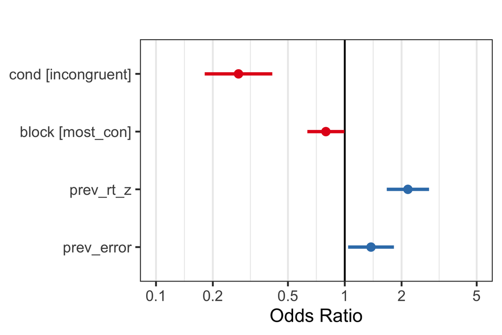

```r
plot(gg)
```

```r
ggsave(gg, filename="Flanker_Acc_Params.pdf", width=9, height=6, useDingbats=FALSE)
```

## m15 as probit

To match Mplus

```r
m15 <- glmer(correct ~ cond + block + prev_rt_z + prev_error +
              (1 + prev_rt_z + cond + prev_error | id) +
              (1 | id:block),
          na.action = na.exclude, control=glmerControl(optimizer="bobyqa", optCtrl = list(maxfun = 30000)),
          data = flanker, family = binomial(link = "probit"))
```

```
## boundary (singular) fit: see ?isSingular
```

```r
summary(m15)
```

```
## Generalized linear mixed model fit by maximum likelihood (Laplace Approximation) ['glmerMod']
##  Family: binomial  ( probit )
## Formula: correct ~ cond + block + prev_rt_z + prev_error + (1 + prev_rt_z +      cond + prev_error | id) + (1 | id:block)
##    Data: flanker
## Control: glmerControl(optimizer = "bobyqa", optCtrl = list(maxfun = 30000))
##
##      AIC      BIC   logLik deviance df.resid
##     3837     3960    -1903     3805    16290
##
## Scaled residuals:
##     Min      1Q  Median      3Q     Max
## -16.678   0.066   0.107   0.171   2.418
##
## Random effects:
##  Groups   Name            Variance Std.Dev. Corr
##  id:block (Intercept)     0.0106   0.103
##  id       (Intercept)     0.2437   0.494
##           prev_rt_z       0.0694   0.263     0.37
##           condincongruent 0.2614   0.511    -0.35  0.06
##           prev_error      0.5770   0.760     0.41  0.98  0.20
## Number of obs: 16306, groups:  id:block, 214; id, 107
##
## Fixed effects:
##                 Estimate Std. Error z value Pr(>|z|)
## (Intercept)       2.6095     0.0928   28.12  < 2e-16 ***
## condincongruent  -0.5460     0.0903   -6.05  1.5e-09 ***
## blockmost_con    -0.1087     0.0520   -2.09    0.037 *
## prev_rt_z         0.3317     0.0583    5.69  1.2e-08 ***
## prev_error        0.8241     0.3485    2.36    0.018 *
## ---
## Signif. codes:  0 '***' 0.001 '**' 0.01 '*' 0.05 '.' 0.1 ' ' 1
##
## Correlation of Fixed Effects:
##             (Intr) cndncn blckm_ prv_r_
## condncngrnt -0.673
## blockmst_cn -0.414  0.223
## prev_rt_z    0.340 -0.050  0.016
## prev_error   0.093  0.010 -0.017  0.258
## convergence code: 0
## boundary (singular) fit: see ?isSingular
```